# 台大人組成的軌跡

r04342017_黃怡菁

2017年3月1日

# HW1作業繳交評分標準

1.資料分析背景說明(40%) 2.資料來源(10%) 3.圖表處理說明(50%)

# 示範說明

## 資料分析背景說明(你可以取個標題)

人文科系在許多人的眼裡，或許不是具有明顯、可見的經濟價值的學科， 許多人會問，念中文可以幹嘛? 念歷史要幹嘛等等之類的問題。去（105）年三月，由教育部、勞動部、財政部等部會，共同合作調查大學畢業生就業情形。調查結果顯示，人文學科畢業生不僅投入職場比率低、轉職率高，月薪幾乎也是各類學科中最低。人文科系大學生畢業三年月薪平均是3萬3千元，只比薪資最低的設計學門多4千元墊底，同樣不吃香的還有社會學科。

## 資料來源

台大主計室 1945~2015的學生人數統計 http://www.ntuacc.ntu.edu.tw/chief/chief8_list.jsp?rc_id=RC1183366113793

## 圖表處理說明 (內容太多我便不做示範文字了~~)

文筆不是評分重點，重點是資料處理的邏輯跟過程(當然這部分還是要搭配文字)，大家可以把他當一份小故事來寫就好。

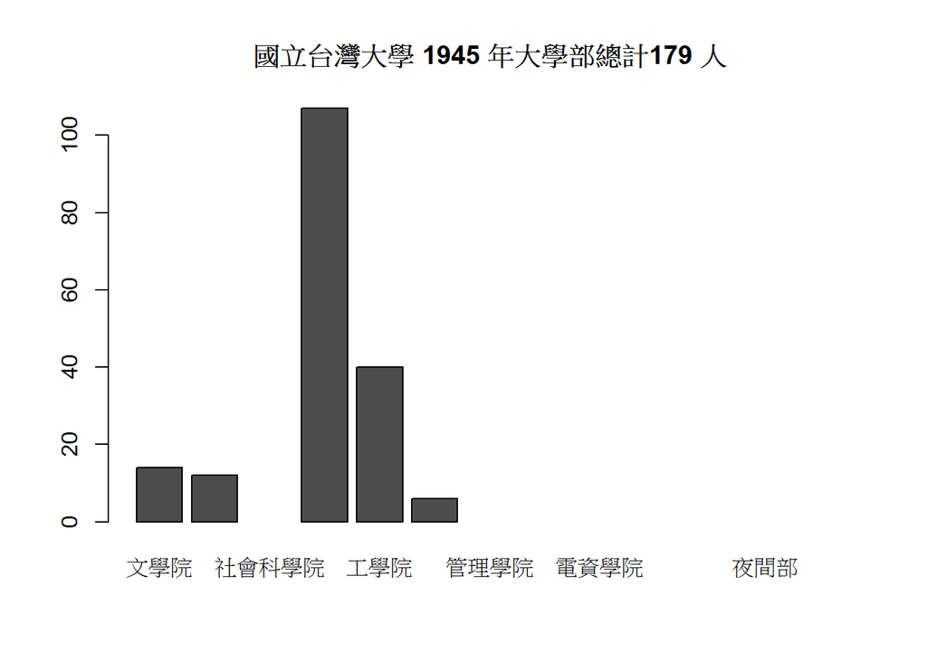

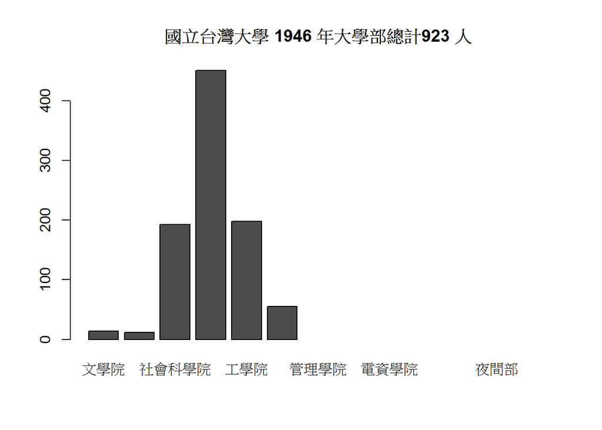

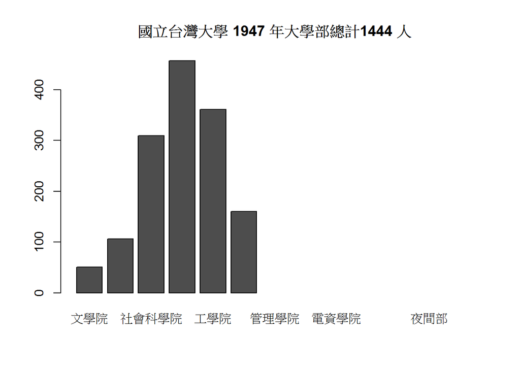

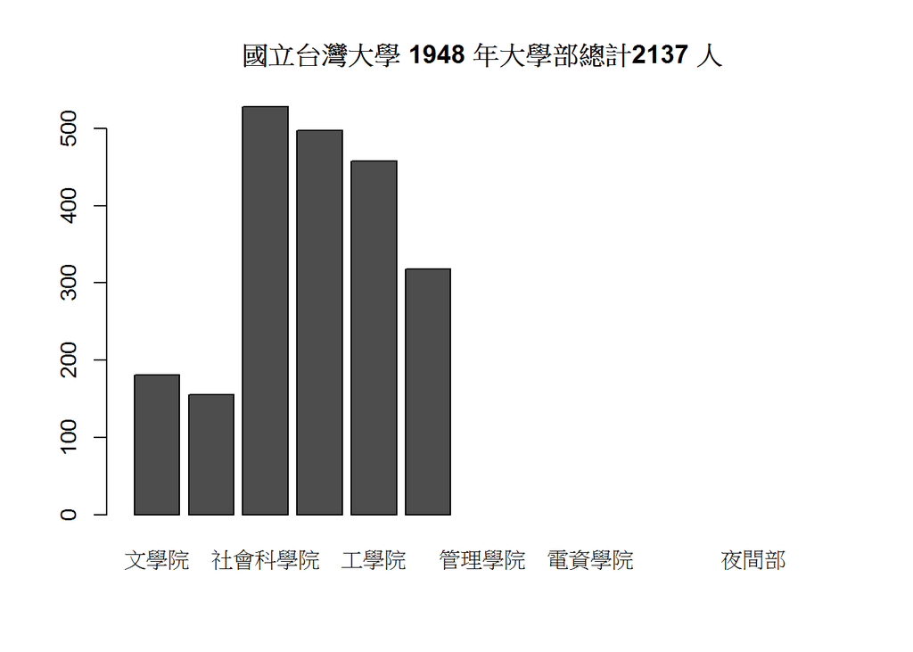

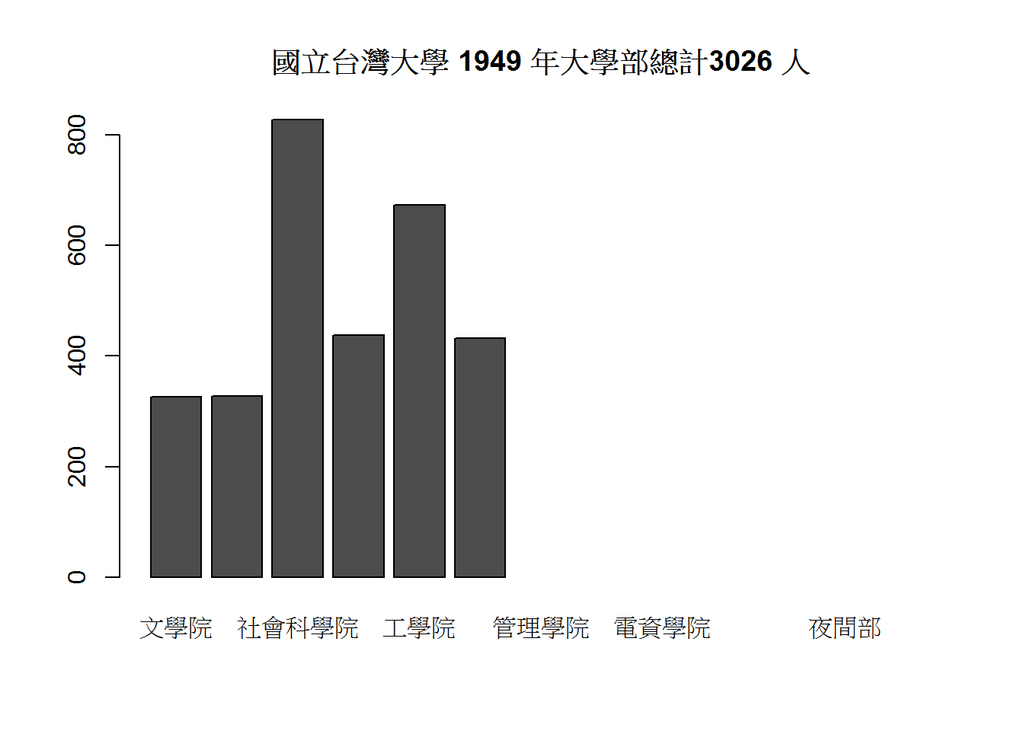

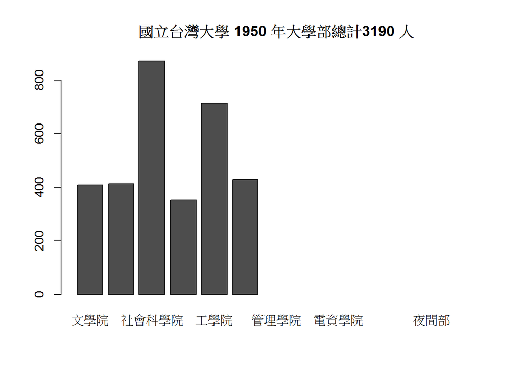

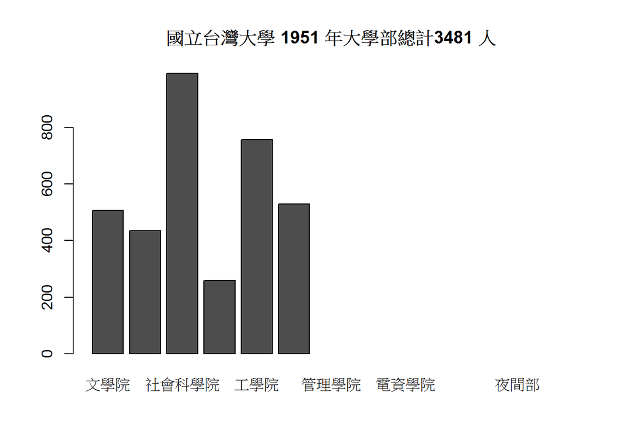

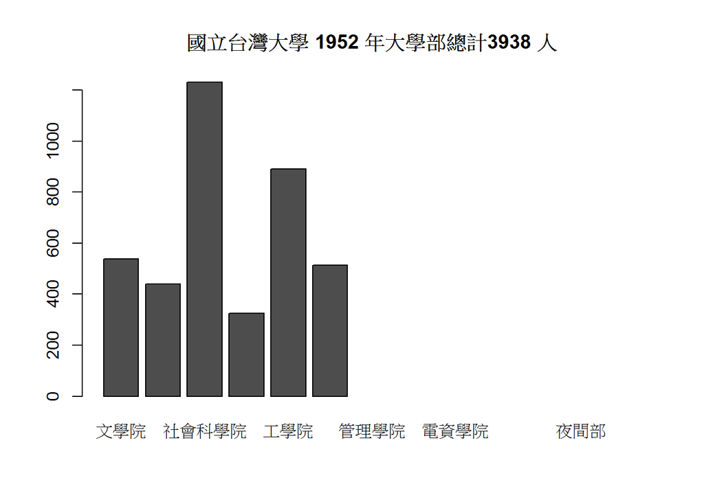

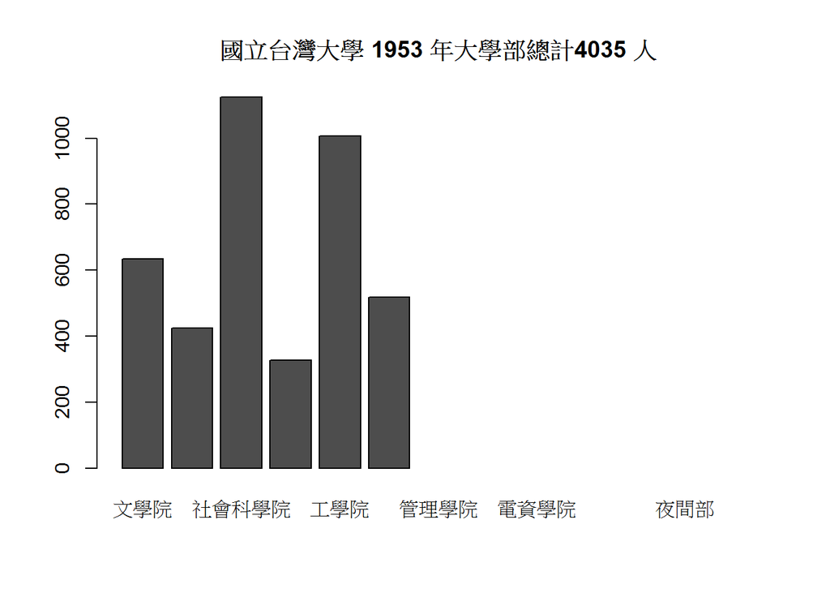

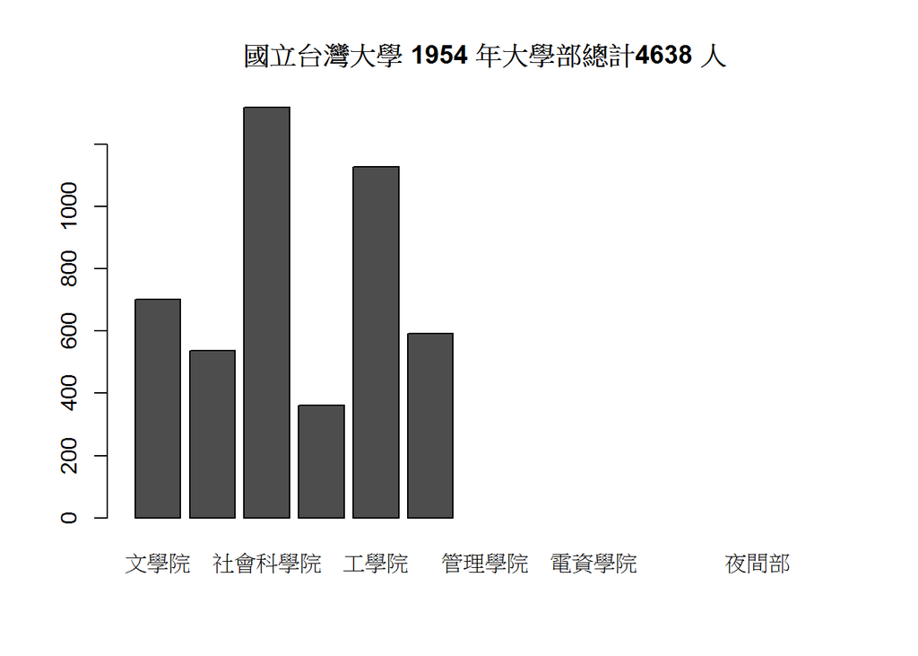

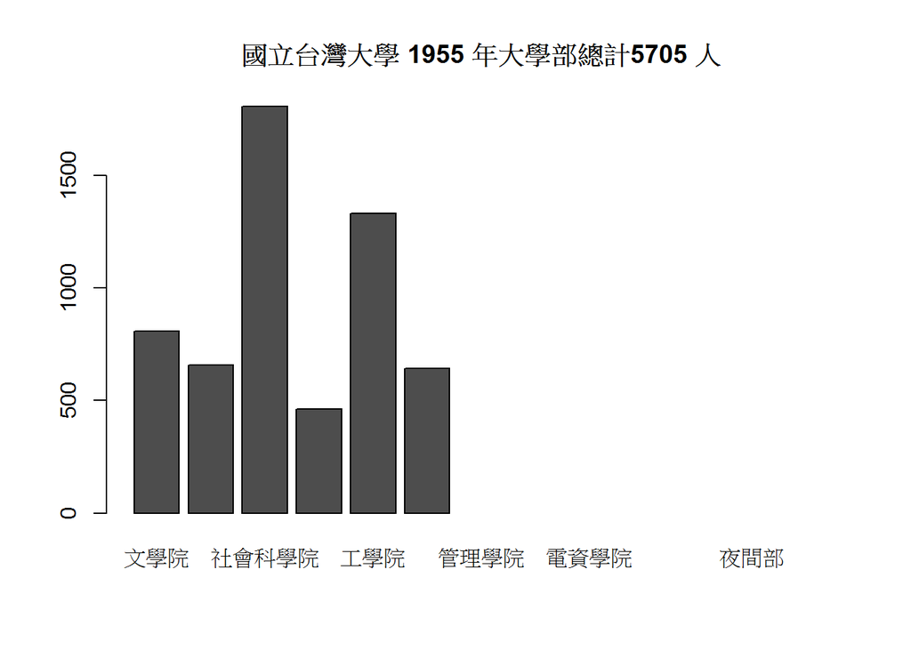

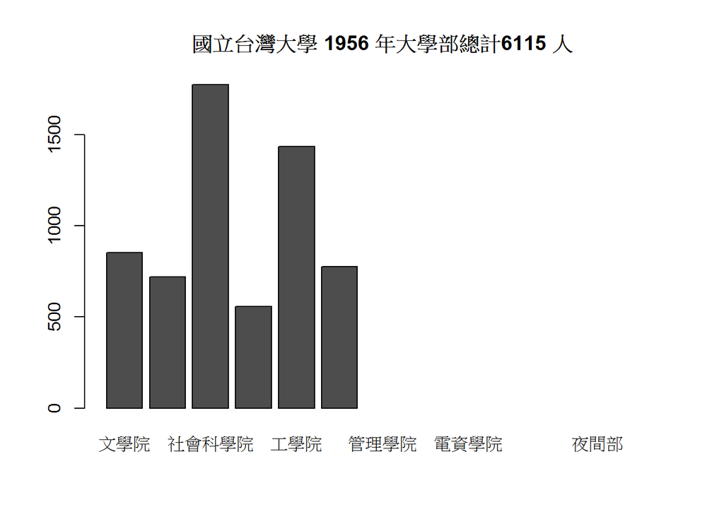

[59 more figures not shown]

```r
rawdata = read.csv('students.csv', header = T)
a = rawdata[-1,]
a = a[-72,]

for(yid in c(1:length(a[,1])))
{
  barplot(as.matrix(a[yid,c(-1,-2)]),
          main = paste0("國立台灣大學 ",
                        a[yid, 1],
                        " 年大學部總計",
                        a[yid, 2],
                        " 人"))

}
```